# Analiza rezultata ispita

Djordje Martic, Luka Vulovic

18/02/2023

## Podaci

Koristićemo podatke iz baze StudentsPerformance, koju je moguće pronaći na sajtu Kaggle.

Radi jednostavnosti, nećemo posmatrati podatke o rasi i nivou edukacije roditelja. Pre analize, kategoričke promenljive gender, lunch i test.preparation.course ćemo zapisati kao faktore.

```r
data <- data[,-c(2,3)] #Izbacujemo kolone o rasi i edukacije roditelja zbog jednostavnosti
data$gender <-as.factor(data$gender)
data$lunch <-as.factor(data$lunch)
data$test.preparation.course <- as.factor(data$test.preparation.course)
summary(data)
```

```
##     gender             lunch     test.preparation.course   math.score
##  female:518   free/reduced:355   completed:358           Min.   :  0.00
##  male  :482   standard    :645   none     :642           1st Qu.: 57.00
##                                                          Median : 66.00
##                                                          Mean   : 66.09
##                                                          3rd Qu.: 77.00
##                                                          Max.   :100.00
##  reading.score    writing.score
##  Min.   : 17.00   Min.   : 10.00
##  1st Qu.: 59.00   1st Qu.: 57.75
##  Median : 70.00   Median : 69.00
##  Mean   : 69.17   Mean   : 68.05
##  3rd Qu.: 79.00   3rd Qu.: 79.00
##  Max.   :100.00   Max.   :100.00
```

U bazi sada imamo 1000 opservacija, od kojih svaka ima 3 numeričke i 3 kategoričke promenljive.

## Kategoričke promenljive

U ovom delu, obratićemo pažnju na kategoričke promenljive u našoj bazi.

### Gender

Ova promenljiva nam daje informaciju o polu studenta. Logučno, imamo 2 nivoa u ovom faktoru, “male” i “female” koji odgovaraju muškom i ženskom rodu. U istraživanju je uključeno 518 žena i 482 muškaraca, što možemo videti i na graficima ispod.

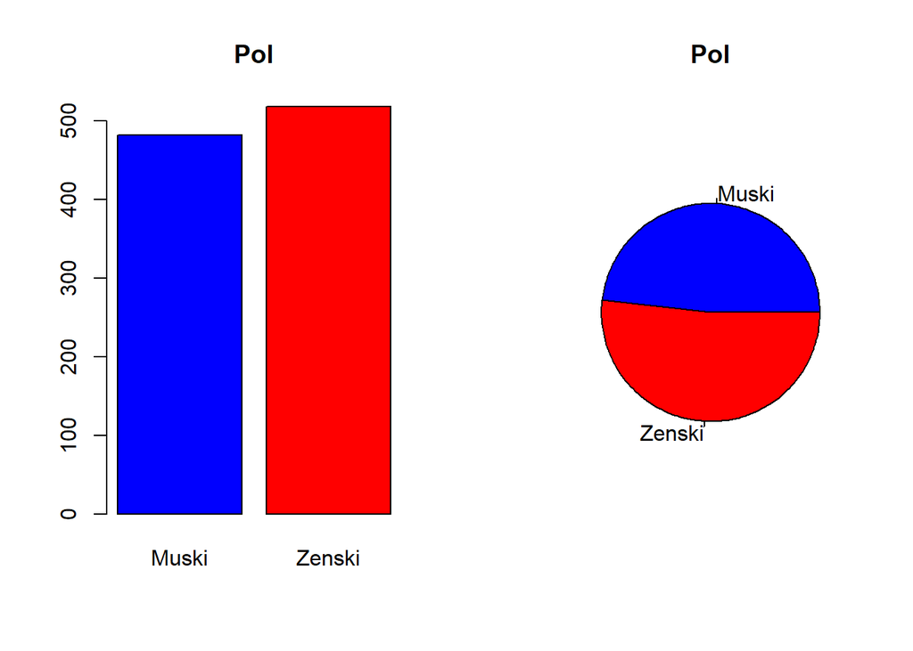

### Lunch

Podaci u koloni lunch sadrže informaciju da li učenik dobija besplatan ili jeftiniji ručak u školi zbog svoje materijalne situacije. Ovde 355 učenika prima ovu vrstu pomoći, dok ostali ne.

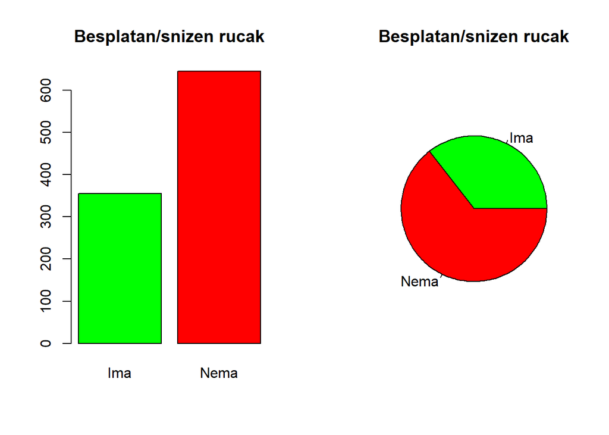

### Test.preparation.course

Poslednja kategorička promenljiva sadrži informacije o tome da li je đak išao na pripremnu nastavu za polaganje testova. Njih 358 je pohađalo ovu nastavu, dok ostali nisu.

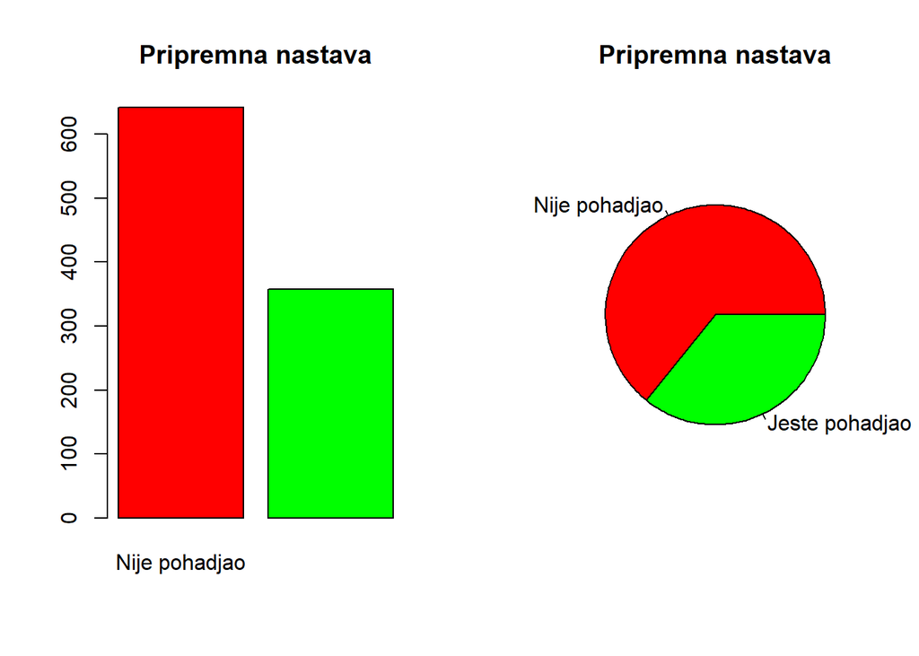

Sada ćemo ispitati zavisnost promenljivih lucnh i test.preparation.course, jer ima smisla da učenici u težoj materijalnoj situaciji ne mogu prijuštiti časove.

```r
table(lunch, test.preparation.course)
```

```
##               test.preparation.course
## lunch          completed none
##   free/reduced       131  224
##   standard           227  418
```

```r
chisq.test(test.preparation.course,lunch)
```

```
##
##  Pearson's Chi-squared test with Yates' continuity correction
##
## data:  test.preparation.course and lunch
## X-squared = 0.22095, df = 1, p-value = 0.6383
```

Vidimo da je p-vrednost testa velika, pa ne možemo odbaciti hipotezu o nezavisnosti ovih promenljivih, što se poklapa sa podacima u tabeli preseka.

## Numeričke promenljive

Imamo 3 numeričke promenljive koje odgovaraju rezultatima studenata na testovima iz matematike, čitanja i pisanja. Ispod možemo videti histograme i boxplotove ovih promenljivih.

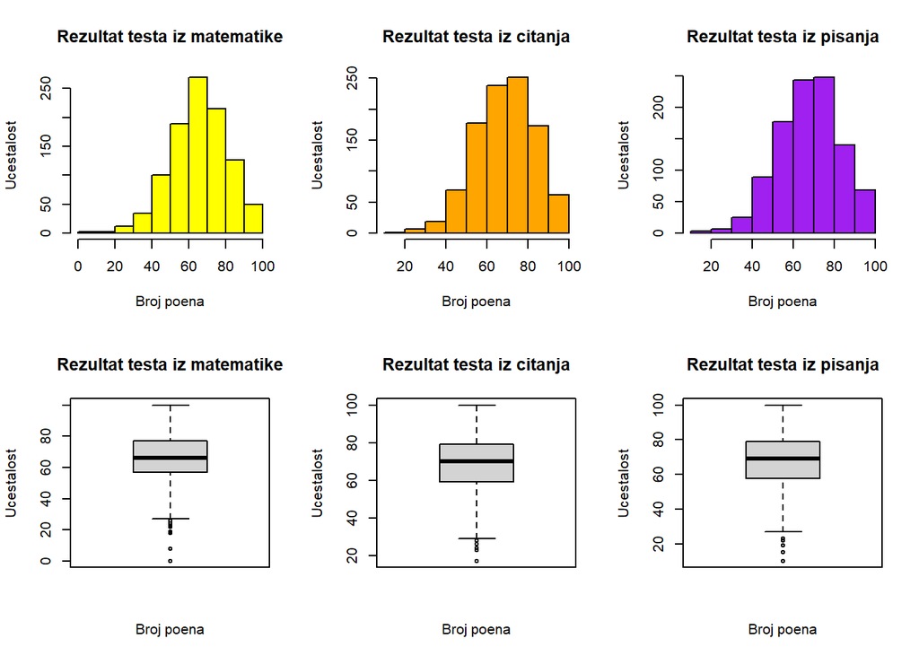

Sa histograma možemo videti da raspodele numeričkih promenljivih liče na normalnu raspodelu, pa ćemo to testirati primenom ks testa.

```r
#KS test pripadnosti normalnoj raspodeli
ks.test(math.score, function(x) pnorm(x, mean(math.score), sd(math.score)))
```

```
##
##  Asymptotic one-sample Kolmogorov-Smirnov test
##
## data:  math.score
## D = 0.030855, p-value = 0.297
## alternative hypothesis: two-sided
```

```r
ks.test(reading.score, function(x) pnorm(x, mean(reading.score), sd(reading.score)))
```

```
##
##  Asymptotic one-sample Kolmogorov-Smirnov test
##
## data:  reading.score
## D = 0.043874, p-value = 0.04257
## alternative hypothesis: two-sided
```

```r
ks.test(writing.score, function(x) pnorm(x, mean(writing.score), sd(writing.score)))
```

```
##
##  Asymptotic one-sample Kolmogorov-Smirnov test
##
## data:  writing.score
## D = 0.041582, p-value = 0.06297
## alternative hypothesis: two-sided
```

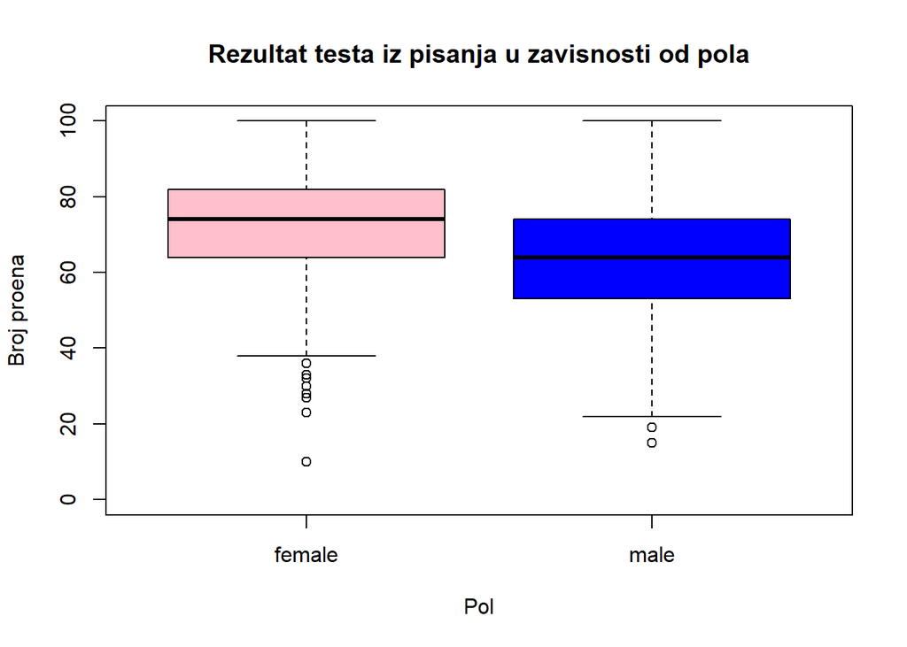

```r
boxplot(writing.score ~ gender, ylim = c(0,100), main = "Rezultat testa iz pisanja u zavisnosti od pola", ylab = "Broj proena", xlab = "Pol", col = c("pink", "blue"))
```

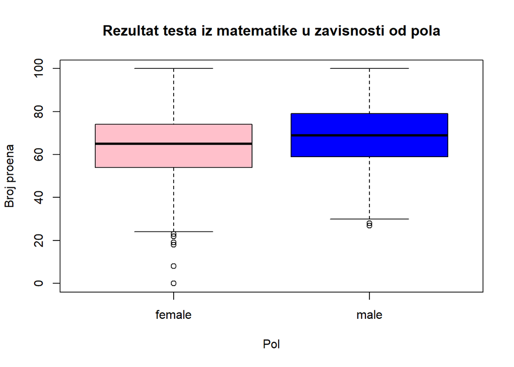

```r
boxplot(math.score ~ gender, ylim = c(0,100), main = "Rezultat testa iz matematike u zavisnosti od pola", ylab = "Broj proena", xlab = "Pol", col = c("pink", "blue"))
```

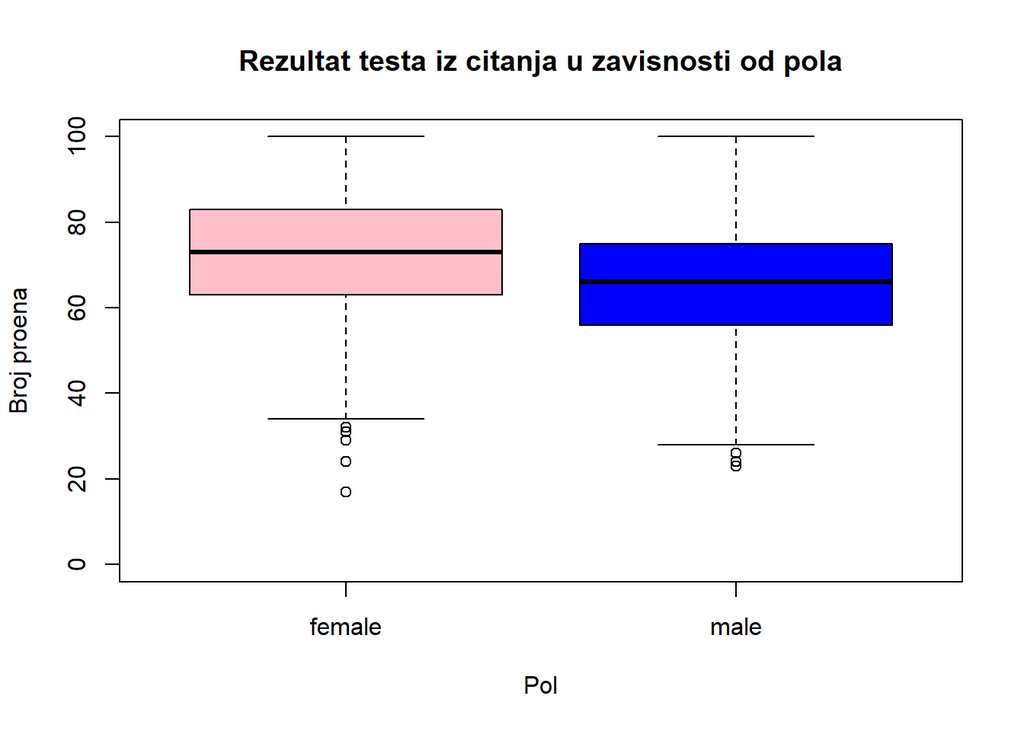

```r
boxplot(reading.score ~ gender, ylim = c(0,100), main = "Rezultat testa iz citanja u zavisnosti od pola", ylab = "Broj proena", xlab = "Pol", col = c("pink", "blue"))
```

Vidimo da su dejočice bolje uradile čitanje i pisanje, a dečaci matematiku, kasnije ćemo ovo testirati t-testom.

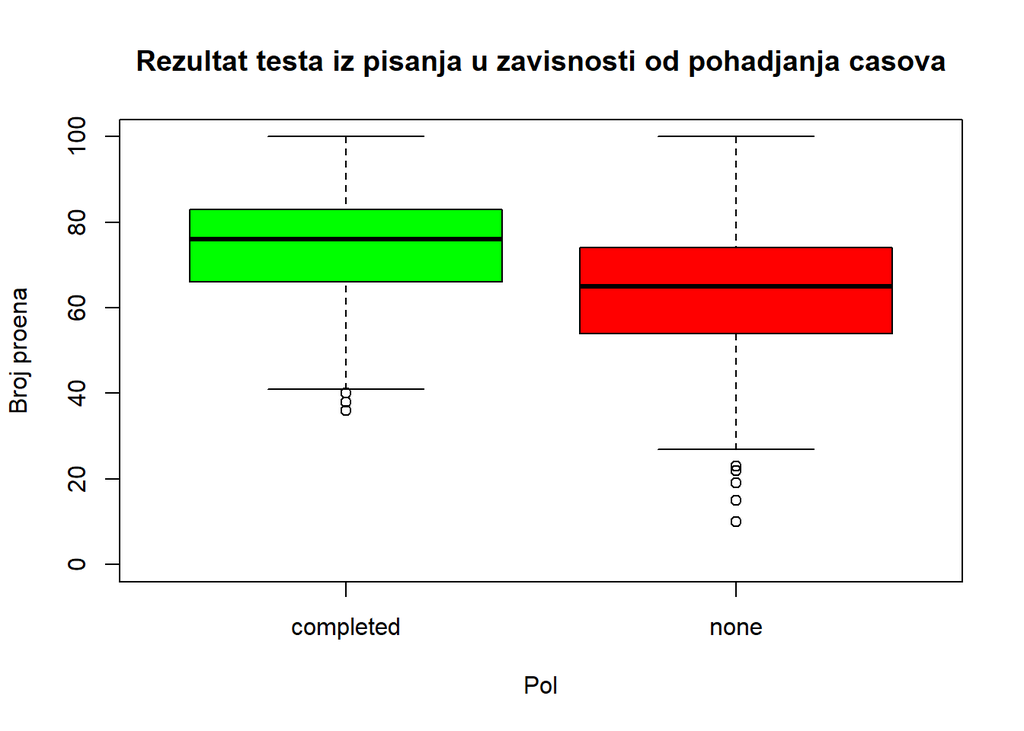

```r
boxplot(writing.score ~ test.preparation.course, ylim = c(0,100), main = "Rezultat testa iz pisanja u zavisnosti od pohadjanja casova", ylab = "Broj proena", xlab = "Pol", col = c("green", "red"))
```

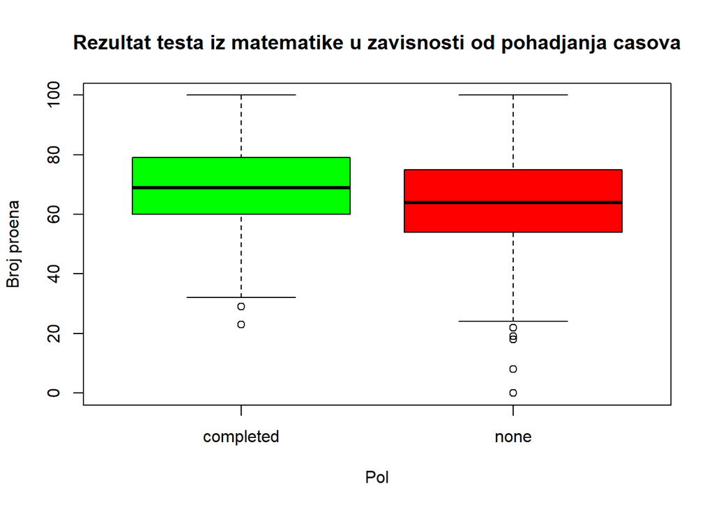

```r
boxplot(math.score ~ test.preparation.course, ylim = c(0,100), main = "Rezultat testa iz matematike u zavisnosti od pohadjanja casova", ylab = "Broj proena", xlab = "Pol", col = c("green", "red"))
```

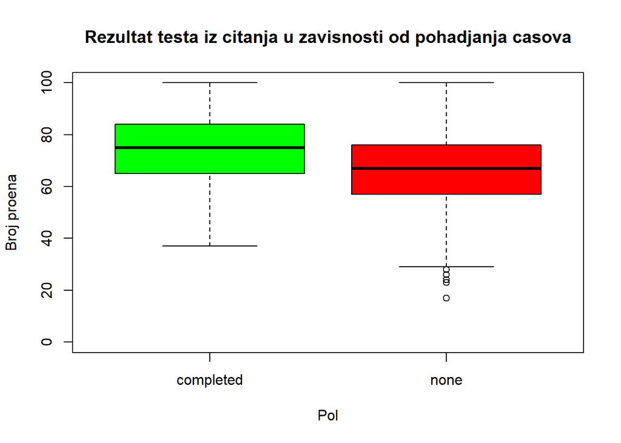

```r
boxplot(reading.score ~ test.preparation.course, ylim = c(0,100), main = "Rezultat testa iz citanja u zavisnosti od pohadjanja casova", ylab = "Broj proena", xlab = "Pol", col = c("green", "red"))
```

Vidimo da su učenici koji su pohađali časove uspešniji od onih koji nisu, ovo ćemo takođe testirati t-testom.

```r
t.test(math.score~gender, alternative = "less")
```

```
##
##  Welch Two Sample t-test
##
## data:  math.score by gender
## t = -5.398, df = 997.98, p-value = 4.21e-08
## alternative hypothesis: true difference in means between group female and group male is less than 0
## 95 percent confidence interval:
##       -Inf -3.541041
## sample estimates:
## mean in group female   mean in group male
##             63.63320             68.72822
```

```r
t.test(writing.score~gender,alternative = "greater")
```

```
##
##  Welch Two Sample t-test
##
## data:  writing.score by gender
## t = 9.9977, df = 997.53, p-value < 2.2e-16
## alternative hypothesis: true difference in means between group female and group male is greater than 0
## 95 percent confidence interval:
##  7.64821     Inf
## sample estimates:
## mean in group female   mean in group male
##             72.46718             63.31120
```

```r
t.test(reading.score~gender, alternative = "greater")
```

```
##
##  Welch Two Sample t-test
##
## data:  reading.score by gender
## t = 7.9684, df = 996.36, p-value = 2.188e-15
## alternative hypothesis: true difference in means between group female and group male is greater than 0
## 95 percent confidence interval:
##  5.660863      Inf
## sample estimates:
## mean in group female   mean in group male
##             72.60811             65.47303
```

Vidimo da su sve tri p-vrednosti izuzetno male, pa u svim testovima prihvatamo altvernativnu hipotezu, tj. potvrdili smo da su devojčice bolje ( u ovom konkretnom testiranju) u čitanju i pisanju a dečaci u matematici.

```r
t.test(writing.score~test.preparation.course,alternative = "greater")
```

```
##
##  Welch Two Sample t-test
##
## data:  writing.score by test.preparation.course
## t = 10.753, df = 811.13, p-value < 2.2e-16
## alternative hypothesis: true difference in means between group completed and group none is greater than 0
## 95 percent confidence interval:
##  8.395955      Inf
## sample estimates:
## mean in group completed      mean in group none
##                74.41899                64.50467
```

```r
t.test(math.score~test.preparation.course,alternative = "greater")
```

```
##
##  Welch Two Sample t-test
##
## data:  math.score by test.preparation.course
## t = 5.787, df = 770.08, p-value = 5.213e-09
## alternative hypothesis: true difference in means between group completed and group none is greater than 0
## 95 percent confidence interval:
##  4.019003      Inf
## sample estimates:
## mean in group completed      mean in group none
##                69.69553                64.07788
```

```r
t.test(reading.score~test.preparation.course,alternative = "greater")
```

```
##
##  Welch Two Sample t-test
##
## data:  reading.score by test.preparation.course
## t = 8.0041, df = 775.37, p-value = 2.194e-15
## alternative hypothesis: true difference in means between group completed and group none is greater than 0
## 95 percent confidence interval:
##  5.845379      Inf
## sample estimates:
## mean in group completed      mean in group none
##                73.89385                66.53427
```

I ovde imamo izuzetno male p-vrednosti, pa prihvatamo alternativne hipoteze da su učenici koji su pohađali pripremnu nastavu uspešniji od onih koji nisu u svim predmetima.

## Korelacija rezultata testova iz čitanja i pisanja

Sada želimo da proverimo korelaciju rezultata testova iz čitanja i pisanja, jer očekujemo da učenici koji bolje čitaju takođe i bolje pišu. Ovo ćemo uraditi Pirsonovim testom nekorelisanosti.

Koeficijent korelacije ocenjujemo Pirsonovim koeficijentom korelacije

$$\hat{\rho_n}=\frac{\sum_{i=1}^{n}{(x_i-\overline{x}})(y_i-\overline{y})}{\sqrt{\sum_{i=1}^{n}(x_i-\overline{x})^2\sum_{i=1}^{n}(y_i-\overline{y})^2}}$$
Sada implementiramo funkciju koja računa Pirsonov koeficijent korelacije:

```r
pearson <- function(x,y) { sum((x-mean(x))*(y-mean(y)))/sqrt(sum((x-mean(x))^2)*sum((y-mean(y))^2)) }
```

Sada primenimo funkciju i upredimo sa rezultatima ugrađene funkcije `cor.test`

```r
pearson(writing.score,reading.score)
```

```
## [1] 0.9545981
```

```r
cor.test(writing.score, reading.score, method = "pearson")
```

```
##
##  Pearson's product-moment correlation
##
## data:  writing.score and reading.score
## t = 101.23, df = 998, p-value < 2.2e-16
## alternative hypothesis: true correlation is not equal to 0
## 95 percent confidence interval:
##  0.9487506 0.9597921
## sample estimates:
##       cor
## 0.9545981
```

U oba slučaja smo dobili istu vrednost ocene koja je približno 0.95 što nam govori da su uspesi na ovim testovima visoko korelisani, skoro linearno.

## Zaključak

Na osnovu podataka uspeli smo da dobijemo sledeće značajne zaključke:

1. Devojčice imaju bolje rezultate na testovima iz čitanja i pisanja, dok dečaci imaju bolje rezultate iz matematike. Ovaj rezultat se često pojavljuje na standardizovanim testovima i moguće je vršiti dalja socioliška i psihološka testiranja da se utvrdi uzrok ovoga.
2. Učenici koji su pohađali pripremnu nastavu su postigli bolje rezultate na testovima od onih koji nisu, što govori u korist toga da je pripremna nastava kvalitetna i da se isplati pohađati je.
3. Rezultati testova iz čitanja i pisanja su veoma visoko korelisani. Ova informacija nam govori da treba razmotriti spajanje ova dva testa u jedan radi uštede resursa.

Moguće je vršiti dalja istraživanja na osnovu ovih podataka, na primer zavisnost uspeha učenika od toga da li imaju privilegije za besplatan ručak, njihove rase, edukacije roditelja, itd.